# Proyecto final Análisis Espacial

Bolívar Morales, Andrey Fonseca, Luis Rivera, Diana Hernández.

2024-04-16

[figure not shown]

# Cargar datos

Para empezar cargamos librerías, capas y dibujarlas

```
library(spatstat)
library(sf)
library(terra)
pacman::p_load(sf, spdep, dplyr, tmap, RColorBrewer, plot)
```

```r
eve <- vect("C:/Users/jfonseca/OneDrive - centrogeo.edu.mx/PhD_CIG/2_Cuatrimestre/Analisis_Espacial/PROYECTO_AE/GIS/desinventar_2.shp")
bar <- vect("C:/Users/jfonseca/OneDrive - centrogeo.edu.mx/PhD_CIG/2_Cuatrimestre/Analisis_Espacial/PROYECTO_AE/GIS/barrio_vereda_2.shp")
alt_cur <- vect("C:/Users/jfonseca/OneDrive - centrogeo.edu.mx/PhD_CIG/2_Cuatrimestre/Analisis_Espacial/PROYECTO_AE/GIS/Altura.shp")
urban <- vect ("C:/Users/jfonseca/OneDrive - centrogeo.edu.mx/PhD_CIG/2_Cuatrimestre/Analisis_Espacial/PROYECTO_AE/GIS/barrio_urbano.shp")
adm_urb <- vect("C:/Users/jfonseca/OneDrive - centrogeo.edu.mx/PhD_CIG/2_Cuatrimestre/Analisis_Espacial/PROYECTO_AE/GIS/adm_urbano.shp")
Eve_barrio <- st_read("C:/Users/jfonseca/OneDrive - centrogeo.edu.mx/PhD_CIG/2_Cuatrimestre/Analisis_Espacial/PROYECTO_AE/GIS/Eventos_barrio.shp")
```

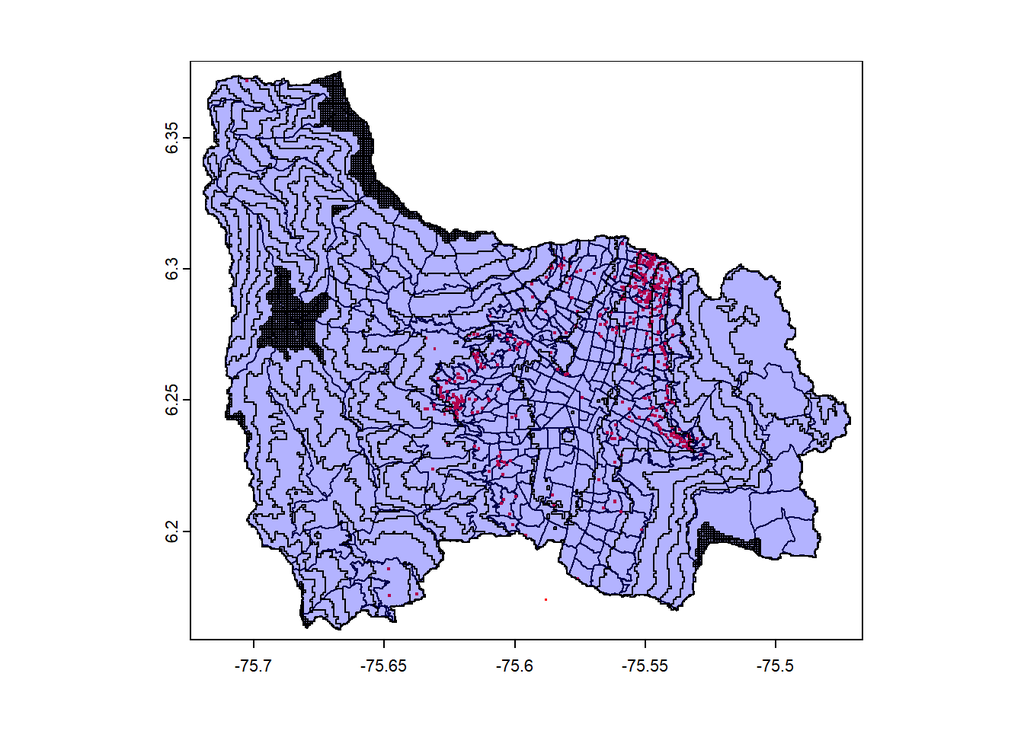

```r
plot(bar, border = "black" )
plot(eve, add= T, pch = ".", col = "red", cex =2)
plot(alt_cur, add= T, col = "blue", alpha= 0.3)
```

## Transformar capas

```r
crdref <- ("epsg:3857")
R_barrio<- project(bar, crs(crdref))
R_evento<- project(eve, crs(crdref))
R_altura<- project(alt_cur, crs(crdref))
Radm_urb <-project(adm_urb, crs(crdref))
R_urban <- project(urban, crs(crdref))
crs(R_barrio)
```

```
## [1] "PROJCRS[\"WGS 84 / Pseudo-Mercator\",\n    BASEGEOGCRS[\"WGS 84\",\n        DATUM[\"World Geodetic System 1984\",\n            ELLIPSOID[\"WGS 84\",6378137,298.257223563,\n                LENGTHUNIT[\"metre\",1]]],\n        PRIMEM[\"Greenwich\",0,\n            ANGLEUNIT[\"degree\",0.01745329…
```

# Calculo de Densidad

## Transformación a objeto ppp

Para realizar la estimación de densidad de kernel, debemos transformar nuestros eventos en una capa digna de `spatstat`, el objeto `ppp` tiene las coordenadas de los eventos y la ventana de la zona de estudio. Para asignar los puntos a las posiciones necesitamos extraer las coordenadas de nuestro objeto `SpatialPointsDataFrame`.

```r
pts <- geom(R_evento)[, c("x", "y")]
head(pts, 10)
```

```
##              x        y
##  [1,] -8414421 702379.8
##  [2,] -8419166 699313.4
##  [3,] -8427169 710763.8
##  [4,] -8414279 702775.9
##  [5,] -8410756 702819.5
##  [6,] -8410152 701393.8
##  [7,] -8410247 701706.7
##  [8,] -8409732 701979.3
##  [9,] -8418644 695311.7
## [10,] -8418306 696411.9
```

## Hacer ventana de observación con owin

```r
b_owin <- as.owin(sf::st_as_sf(R_barrio))
class(b_owin)
```

```
## [1] "owin"
```

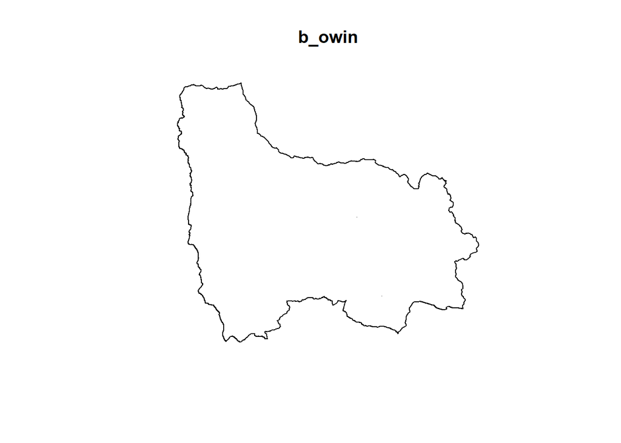

```r
plot(b_owin)
```

Observar todo el panel de puntos

```r
p <- ppp(pts[,1], pts[,2], window = b_owin)
class(p)
```

```
## [1] "ppp"
```

```r
p
```

```
## Planar point pattern: 577 points
## window: polygonal boundary
## enclosing rectangle: [-8429035, -8401488] x [687378.1, 711116.3] units
## *** 11 illegal points stored in attr(,"rejects") ***
```

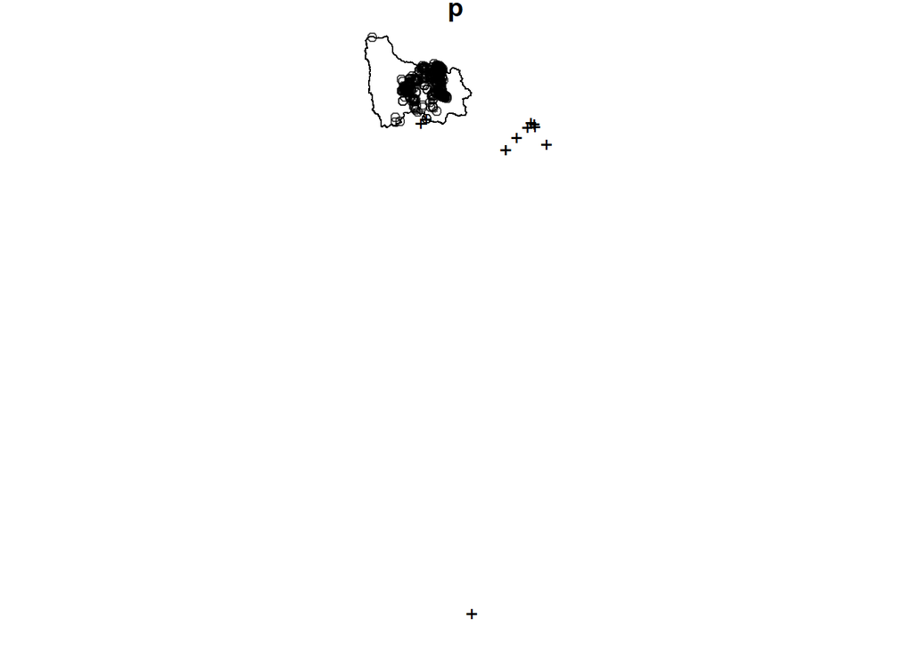

```r
par(mai=c(0.1,0.9,0.1,0.9))
plot(p)
```

Interceptar por el área de estudio y obtener los puntos internos.

```r
d_win <- inside.owin(p, w = b_owin)
p_dentro <- p[d_win,]
n_dentro <- sum(d_win)
print(paste(n_dentro))
```

```
## [1] "577"
```

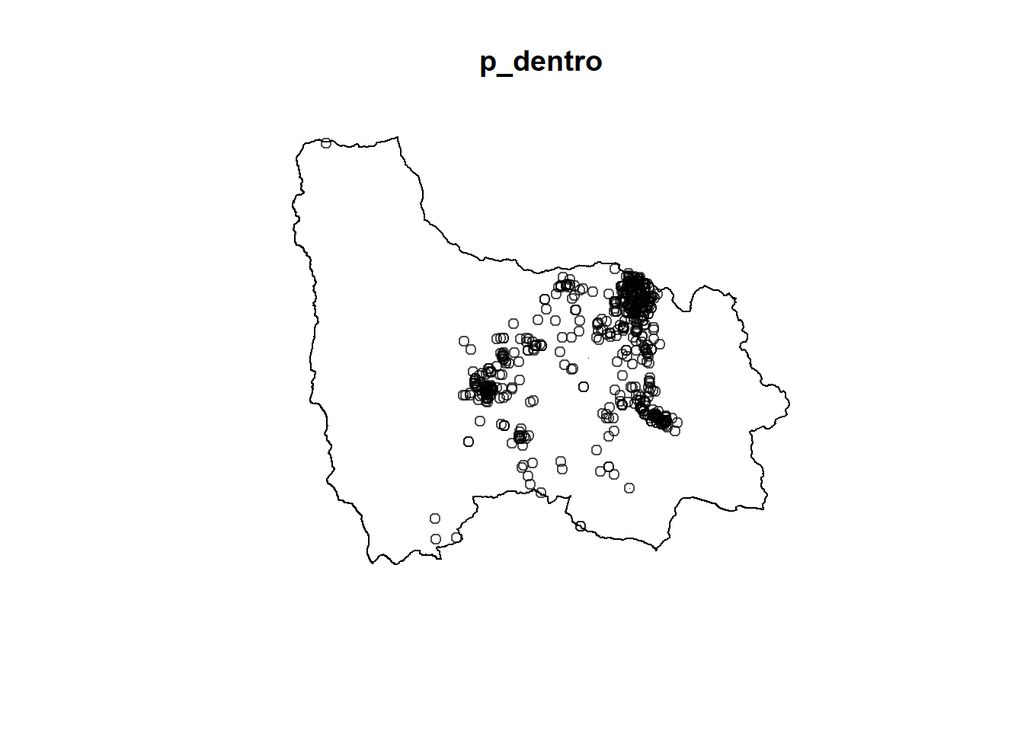

```r
plot(p_dentro)
```

## Crear Mapa de calor

```r
ds <- density.ppp(p_dentro, sigma = 300)
class(ds)
```

```
## [1] "im"
```

```r
ds1 <- density.ppp(p_dentro, sigma = 1500, kernel= "quartic")
class(ds1)
```

```
## [1] "im"
```

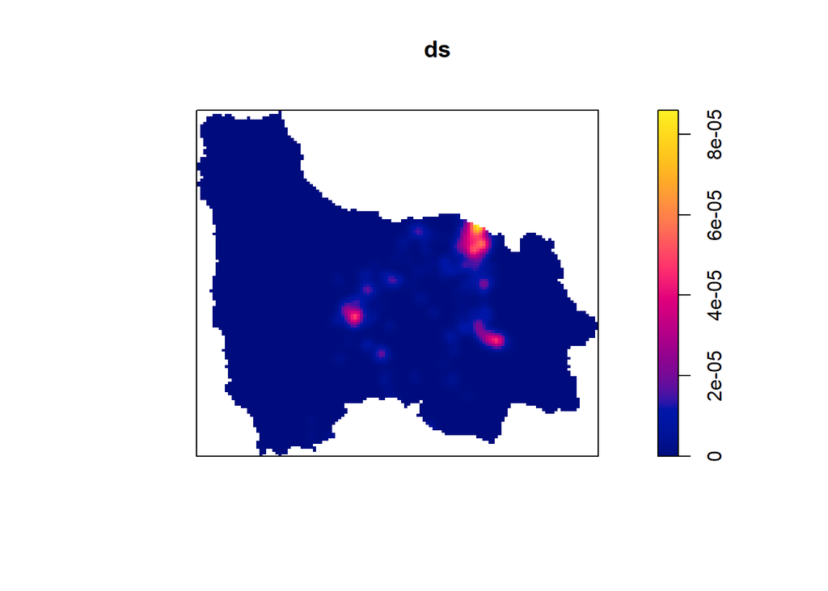

```r
plot(ds)
```

Con el fin de de observar mejor los puntos, se coloca el contorno de la mancha urbana del municipio de Medellín

```r
b_owin2 <- as.owin(sf::st_as_sf(Radm_urb))
class(b_owin)
```

[output not shown]

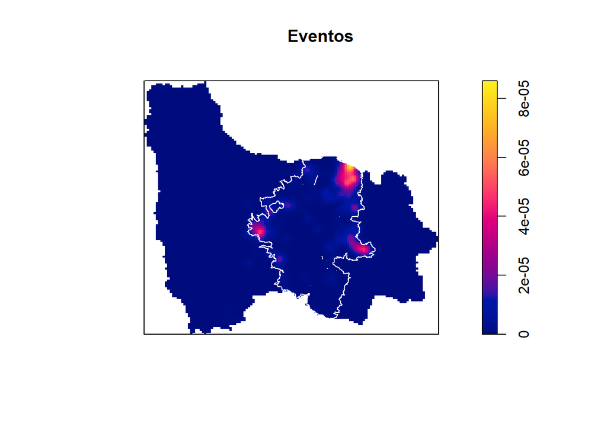

```r
plot(ds, main='Eventos')
plot(b_owin2, border = "white", add = T)
```

Se quiere observar específicamente en que comunas se presentan en mayor detalle los puntos de calor, por ello se coloca los límites administrativos de las comunas.

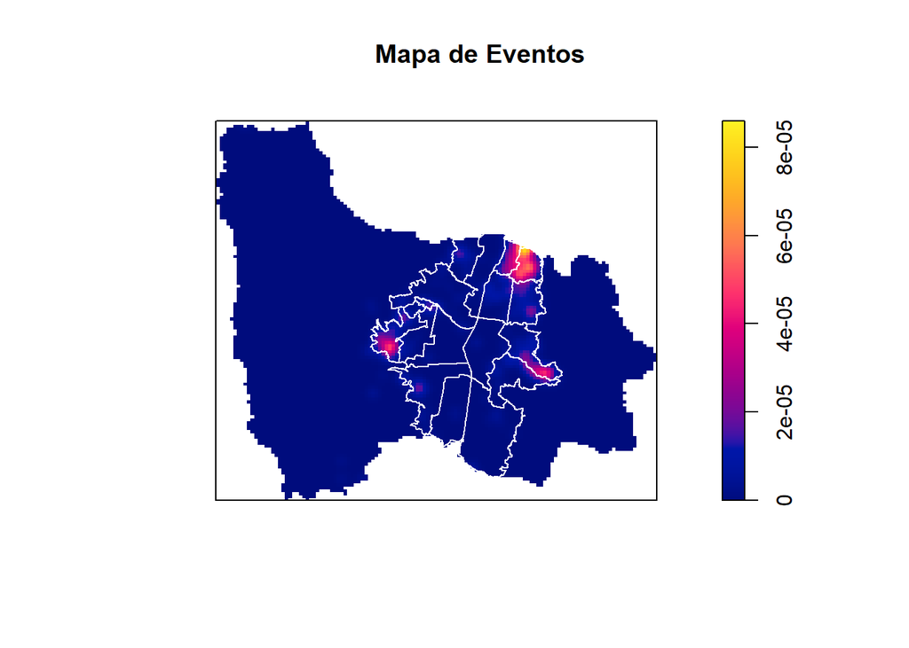

```r
plot(ds, main='Mapa de Eventos')
plot(sf::st_geometry(sf::st_as_sf(Radm_urb)), border = "white", add = TRUE)
```

```r
# La función st_geometry(), reconstruye la geometría
# La función st_as_df(), convierte el archivo espacial en un archivo tipo sf
```

Ahora se colocan las regiones de alturas para la ciudad de Medellín.

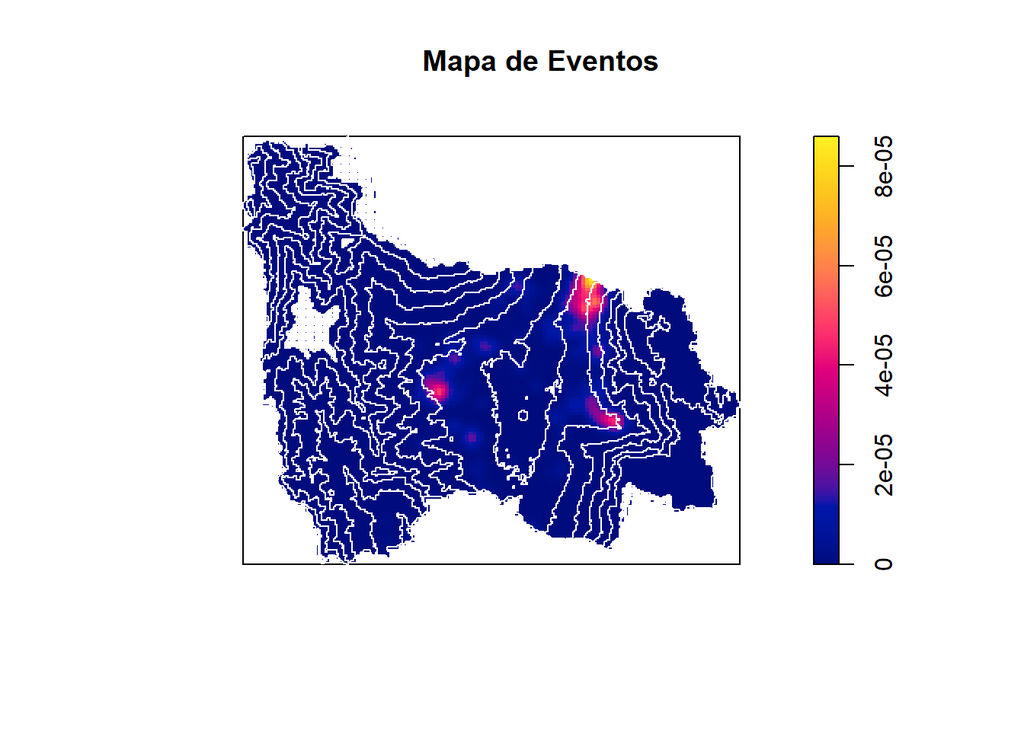

```r
plot(ds, main='Mapa de Eventos')
plot(sf::st_geometry(sf::st_as_sf(R_altura)), border = "white", add = TRUE)
```

# Cálculo de Autocorrelación

```
pacman::p_load(sf, spdep, dplyr, tmap, RColorBrewer, plot)
```

## Cálculo de Matriz de pesos espaciales con Gi

Se calculan los pesos

```r
wr <- poly2nb(Eve_barrio, row.names= Eve_barrio$OBJECTID, queen=FALSE)
lstw <- nb2listw(wr, style='B')
Gi <- localG(Eve_barrio$eventos, lstw)
head(Gi)
```

```
## [1] -1.1742071  1.1235916  0.4712312  7.4870701  0.2889077  2.4389994
```

## Generar un mapa con la matriz de pesos Gi

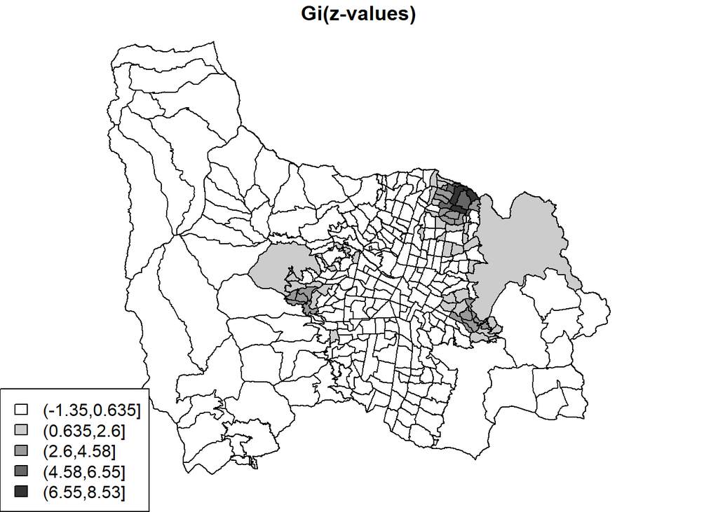

```r
par(mai=c(0,0,0,0))
Gcuts <- cut(Gi, 5)
Gcutsi <- as.integer(Gcuts)
Eve_barrio$Gcutsi <- Gcutsi
cols <- rev(gray(seq(0,1,.2)))
plot(Eve_barrio[,5], col=cols[Gcutsi], main= "Gi(z-values)")
legend('bottomleft', levels(Gcuts), fill=cols)
```

## Generar un mapa con la matriz de pesos Gi*

La otra versión del estadístico Gi* incluye los valores del i-ésimo elemento en la matriz de pesos.

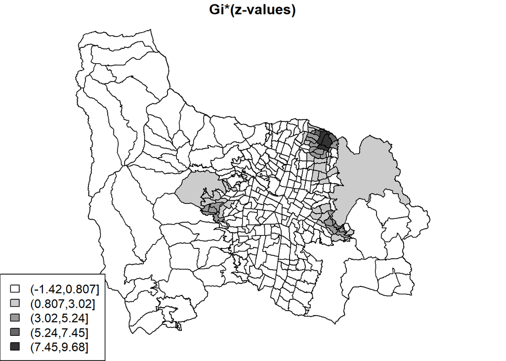

```r
par(mai=c(0,0,0,0))
ws <- include.self(wr)
lstws <- nb2listw(ws, style='B')
Gis <- localG(Eve_barrio$eventos, lstws)
Gscuts <- cut(Gis, 5)
Gscutsi <- as.integer(Gscuts)
cols <- rev(gray(seq(0,1,.2)))
plot(Eve_barrio[,5], col=cols[Gscutsi], main= "Gi*(z-values)")
legend('bottomleft', levels(Gscuts), fill=cols)
```